# Лабораторная 4

Дискреционное разграничение прав в Linux. Расширенные атрибуты

Шалыгин Г. Э.

Российский университет дружбы народов, Москва, Россия

# Информация

## Докладчик

- Шалыгин Георгий Эдуардович
- студент НФИ-02-20
- Российский университет дружбы народов

# Вводная часть

## Актуальность

- - Информационная безопасность - важная часть компетенции в образовательном треке НФИ

## Цели и задачи

- Получение практических навыков работы в консоли с расширенными атрибутами файлов.

## Материалы и методы

- Процессор `pandoc` для входного формата Markdown
- Результирующие форматы
  - `pdf`
  - `html`
- Автоматизация процесса создания: `Makefile`
- Компилятор Julia
- OpenModelica

# Результаты

## Изменение атрибутов

Попробуем установить на файл /home/guest/dir1/file1 расширенный атрибут a от имени пользователя guest: chattr +a /home/guest/dir1/file1 В ответ получаем отказ от выполнения операции (fig:002).

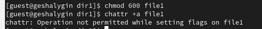

Попытка изменения атрибутов

От имени супер юзера установим расширенный атрибут a на файл /home/guest/dir1/file1 (@fig:003).

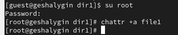

Изменение атрибутов

## Доступ к файлу

1. Выполним дозапись в файл file1 слова «test» командой echo “test” >> /home/guest/dir1/file1 После этого выполните чтение файла file1 командой cat /home/guest/dir1/file. Слово test было успешно записано в file1 (@fig:005).

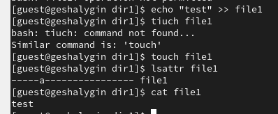

   Проверка доступа к файлу

2. Попробуем перезаписать файл file1 командой echo “abcd” > /home/guest/dirl/file1, переименовать файл. Эти действия выполнить не удается (@fig:006).

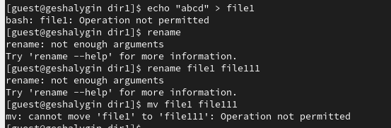

   Проверка доступа изменения

3. Также не удается понизить права файла командой chmod (@fig:007).

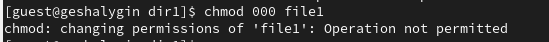

   Неудача

## Атрибуты -а, -i

1. Снимем расширенный атрибут a с файла /home/guest/dirl/file1 от имени суперпользователя командой chattr -a /home/guest/dir1/file1 Повторим операции, которые ранее не удавалось выполнить. Теперь их выполнить можно (@fig:008).

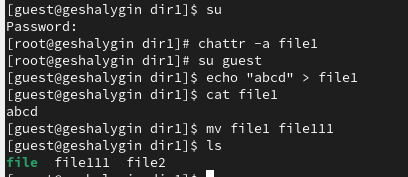

   Проверка прав доступа для новых атрибутов

2. Повторим действия по шагам, заменив атрибут «a» атрибутом «i».

   Теперь дозапись в файл запрещена.(@fig:009).

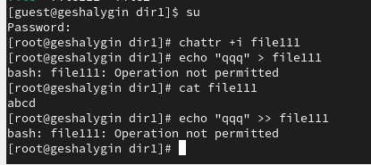

   Проверка доступа для новых атрибутов

# Вывод

В результате выполнения работы мы повысили свои навыки использования интерфейса командой строки (CLI), познакомились на примерах с тем, как используются основные и расширенные атрибуты при разграничении доступа.